# Maryland 2026 general election turnout forecast

Ballots cast and turnout rates by county and party group, November 3, 2026

The forecast uses the State Board of Elections’ mail-in figures through October 16, 2026. Every number on this page is read from the model’s committed outputs in `data/turnout_model/`. Ballots cast counts every ballot: election day, early voting, mail-in and provisional. A turnout rate is always ballots cast divided by a named denominator: active registration, eligible registration (active plus inactive registrants) or citizen voting-age population (CVAP).

## The forecast in one table

The central forecast is 2,282,279 ballots cast, 53.1% of active registration. The range to quote runs from 2,053,581 to 2,546,114.

Statewide ballots cast and turnout rates. Active = active registration; eligible = active plus inactive registrants (projected for 2026); CVAP = citizen voting-age population (ACS).

| Scenario | Ballots cast | 90% interval | Rate on active | Rate on eligible | Rate on CVAP |
| --- | --- | --- | --- | --- | --- |
| Low (a 2022-like midterm) | 2,095,147 | 2,053,581 to 2,136,504 (within scenario) | 48.7% | 45.1% | 47.4% |
| Central (the level rule’s blend) | 2,282,279 | 2,240,832 to 2,323,202 (within scenario) | 53.1% | 49.2% | 51.7% |
| High (a 2018-like midterm) | 2,506,337 | 2,465,906 to 2,546,114 (within scenario) | 58.3% | 54.0% | 56.7% |
| Headline range (low’s 5th to high’s 95th percentile) | central: 2,282,279 | 2,053,581 to 2,546,114 (across scenarios) | 47.7% to 59.2% | 44.2% to 54.8% | 46.5% to 57.6% |
| 2022 general, actual | 2,031,635 |  | 49.3% | 45.7% | not computed |
| 2018 general, actual | 2,335,128 |  | 59.1% | not available | not computed |

Low assumes each party votes at its 2022 statewide level, a quiet midterm. High assumes each party votes at its 2018 level, an energized midterm. Central blends the two, party by party, with weights set by the written rule below. The intervals within each scenario are narrow by construction, because each draw is calibrated to a past election. They carry only cell-level noise and the shift in the 2026 electorate’s mix. The real uncertainty is the spread between low and high. That is why the headline range runs from low’s 5th percentile to high’s 95th. The 2022 rate on eligible divides by that election’s active plus inactive registrants, from the board’s inactive counts. No inactive counts exist for 2018, so its rate on eligible is not available. CVAP comes from a single ACS vintage matched to 2026, so it is not used for the past elections.

The 2026 rate on eligible is projected. There is no 2026 inactive count yet, so eligible is projected active registration times one plus the average of the 2022 and 2024 inactive-to-active ratios. The board’s own published 2026 percentage will use its actual eligible count and will differ.

## What kind of model this is

The model treats each county and party group as a cell, 72 in all. In each cell, ballots cast are a binomial share of active registration. The model has three layers. Structure is estimated: how each cell’s turnout sits above or below its party’s statewide level in a midterm. Composition is computed: how the cell’s 2026 electorate differs in age and newness from 2022’s. Level is set by a written rule and bracketed between the 2022 and 2018 midterms.

The structure layer is a hierarchical binomial regression, fitted with `lme4::glmer` on 360 county x party rows from six elections (2018 and 2022 generals, 2022 and 2026 primaries, 2024 primary and general). It has a free statewide level for each election and party, four county census covariates, and random effects for county x party, county x election type and each observation. The formula, from `fit_summary.json`:

```
cbind(ballots_cast, active - ballots_cast) ~ 0 + ep + z_share_ba_plus + z_median_age + z_share_moved_past_year + z_share_owner_occupied + (1 | county:party_group) + (1 | county:election_type) + (1 | obs)
```

Variance components of the selected fit.

| Random effect | Variance (logit scale) | Standard deviation |
| --- | --- | --- |
| Observation (cell noise) | 0.0144 | 0.120 |
| County x election type | 0.0048 | 0.070 |
| County x party | 0.0290 | 0.170 |

The full formula and the one without (1 | county:party_group:election_type) are singular: the county x party x type term is estimated at 0 (it is nearly the same as (1 | obs), with at most three rows per cell and election type), and (1 | county) is estimated at 0 once the covariates are in: the covariates and (1 | county:party_group) take up all county-level variation. Dropping (1 | county) as well leaves the estimates unchanged. zero_sd_terms in each attempt lists the terms at 0.

## The level rule

The rule puts Democrats closer to 2022 (w = 0.4), Republicans closer to 2022 (w = 0.4) and Other (unaffiliated and minor parties) closer to 2018 (w = 0.6). The weight w is the share of the central level taken from 2018. The votes that moved it:

- Democrats: registration momentum (2022-like), so w = 0.4.
- Republicans: primary participation (2022-like), so w = 0.4.
- Other (unaffiliated and minor parties): registration momentum (2018-like), so w = 0.6.

The rule, verbatim from `level_rule_text.csv`:

```
Three scenarios per party p, on the logit scale, per draw k:
low: alpha = alpha*_{GG22,p,k}
high: alpha = alpha*_{GG18,p,k}
central: alpha = (1 - w_p) * alpha*_{GG22,p,k} + w_p * alpha*_{GG18,p,k}
w_p starts at 0.5 and moves by 0.1 per index vote, bounded to [0.2, 0.8].
Votes, per party p (DEM, REP, OTH), each in {-1, 0, +1} where +1 means 2018-like and -1 means 2022-like:
1. Registration momentum: position = (m26 - m22) / (m18 - m22) using indices.csv reg_momentum, reg_momentum_2022, reg_momentum_2018 (statewide row for p). Vote +1 if position >= 2/3, -1 if <= 1/3, else 0. If |m18 - m22| < 0.002 the analogues cannot discriminate: vote 0.
Amendment: a position outside [-0.5, 1.5] extrapolates beyond the two analogues and its sign is not interpretable: vote 0 when position < -0.5 or > 1.5; otherwise the thresholds above apply.
2. Mail requests, per registrant: project GG26 final sent for p as a linear trend over the available daily snapshots extended to 2026-10-27 (the request deadline; an assumption: no ballots are sent after it). Index = (projected GG26 final sent_p / 2026 projected active_p from denominators_gg26.csv) / (GG22 final sent_p (2022-11-28 file) / GG22 active_p from training.csv), so registration growth is not read as engagement. Vote +1 if >= 1.05, -1 if <= 0.95, else 0. (No 2018 analogue exists: 2018 predates the permanent mail-in list, so this index can only say "more or less engaged than 2022".)
3. Primary participation, per registrant: index = (GP26 ballots_p / GP26 active_p) / (GP22 ballots_p / GP22 active_p), from training.csv (DEM and REP; GP26 split estimated; OTH gets vote 0 because primaries are closed). Vote +1 if >= 1.05, -1 if <= 0.95, else 0.
Caveat: GP26 had an incumbent governor and GP22 an open seat, which depresses this index for reasons unrelated to November.
level_rule.csv also records the raw-count ratios (mail_count_ratio, primary_count_ratio) beside the per-registrant indices that vote.
```

The level rule’s indices, votes and weights by party (level_rule.csv). Momentum is September active registration over the previous September’s. OTH has no primary index: Maryland’s primaries are closed.

| Quantity | DEM | REP | OTH |
| --- | --- | --- | --- |
| Registration momentum, Sept 2025 to Sept 2026 | 1.0019 | 0.9869 | 1.0302 |
| Registration momentum, Sept 2021 to Sept 2022 | 0.9999 | 1.0057 | 1.0459 |
| Registration momentum, Sept 2017 to Sept 2018 | 1.0173 | 1.0029 | 1.0298 |
| Position between 2022 (0) and 2018 (1) | 0.12 | 6.66 | 0.97 |
| Vote: registration momentum | -1 | 0 | +1 |
| Mail ballots sent, latest | 414,402 | 96,270 | 110,420 |
| Mail ballots sent, projected to Oct. 27 | 435,607 | 101,316 | 118,090 |
| Mail ballots sent, 2022 final | 438,093 | 102,183 | 99,172 |
| Active registration, 2026 (projected) | 2,218,637 | 1,007,172 | 1,075,725 |
| Active registration, 2022 | 2,235,977 | 992,188 | 895,991 |
| Mail sent, raw count ratio 2026/2022 | 0.994 | 0.992 | 1.191 |
| Mail sent per registrant, index 2026/2022 | 1.002 | 0.977 | 0.992 |
| Vote: mail requests | 0 | 0 | 0 |
| Primary ballots, 2026 | 654,148 | 219,736 | 28,934 |
| Primary ballots, 2022 | 687,517 | 301,958 | 44,428 |
| Primary ballots, raw count ratio 2026/2022 | 0.951 | 0.728 | not used |
| Primary ballots per registrant, index 2026/2022 | 0.956 | 0.705 | not used |
| Vote: primary participation | 0 | -1 | 0 |
| Sum of votes | -1 | -1 | +1 |
| Weight on 2018 (w) | 0.4 | 0.4 | 0.6 |

**The mail vote depends on how the mail requests are projected.** The rule extends a straight line through every daily snapshot to the October 27 request deadline. Holding the latest count gives lower mail indices for every party. The mail vote changes for Republicans (0 to -1) and other voters (0 to -1), so w becomes DEM 0.4, REP 0.3 and OTH 0.5. Extending only the last three snapshots gives lower mail indices for every party. The mail vote changes for Republicans (0 to -1) and other voters (0 to -1), so w becomes DEM 0.4, REP 0.3 and OTH 0.5.

Mail-projection sensitivity (level_rule.csv _latest and _recent columns).

| Projection | Party | Projected sent | Mail index | Mail vote | w |
| --- | --- | --- | --- | --- | --- |
| Rule: line through all snapshots | DEM | 435,607 | 1.002 | 0 | 0.4 |
| Rule: line through all snapshots | REP | 101,316 | 0.977 | 0 | 0.4 |
| Rule: line through all snapshots | OTH | 118,090 | 0.992 | 0 | 0.6 |
| Latest count held | DEM | 414,402 | 0.953 | 0 | 0.4 |
| Latest count held | REP | 96,270 | 0.928 | -1 | 0.3 |
| Latest count held | OTH | 110,420 | 0.927 | -1 | 0.5 |
| Line through last three snapshots | DEM | 416,705 | 0.959 | 0 | 0.4 |
| Line through last three snapshots | REP | 97,035 | 0.935 | -1 | 0.3 |
| Line through last three snapshots | OTH | 111,378 | 0.935 | -1 | 0.5 |

Statewide central forecast under each mail projection (forecast_statewide.csv).

| Scenario | Ballots cast | Difference from central | Rate on active | Rate on eligible (projected) |
| --- | --- | --- | --- | --- |
| Central (rule) | 2,282,279 |  | 53.1% | 49.2% |
| Central, latest mail count held | 2,265,167 | -17,112 | 52.7% | 48.8% |
| Central, last three snapshots | 2,265,167 | -17,112 | 52.7% | 48.8% |

No 2018 analogue exists: 2018 predates the permanent mail-in list, so the mail index can only say more or less engaged than 2022. The rule’s GG26 projection is an OLS line of sent on calendar day over every daily snapshot, extended to 2026-10-27, the mail-in request deadline (assumed to be when sending stops), floored per county x party at the latest observed count. The mail vote depends on the projection choice: the sent series is step-like, so the all-snapshot slope is much steeper than the last few days’, and holding the latest count or extending the last three snapshots gives lower indices (see the _latest and _recent columns of level_rule.csv and the central_mail_latest and central_mail_recent scenarios). No GG22 trajectory of daily sent counts exists to anchor the choice.

Caveats on the rule:

- **Mail has no 2018 analogue.** 2018 came before the permanent mail-in list, so the mail index can only say whether voters are more or less engaged than in 2022.
- **The 2026 primary had an incumbent governor; 2022’s was an open seat.** That depresses the primary index for reasons unrelated to November. The 2026 primary’s party split is also an estimate from the voter file.
- **Momentum outside the analogue range votes 0.** Registration momentum for Republicans (position 6.66) lies outside [-0.5, 1.5], beyond the range between 2022 and 2018, so the sign is not interpretable and it casts no vote.

## Counties

Central turnout rates on active registration run from 42.0% in Baltimore City to 64.5% in Talbot. In 24 of 24 counties the central rate lies between the county’s 2022 and 2018 rates. Relative to its forecast, the 90% interval is wider than the statewide one (3.6% of the forecast) in 24 of 24 counties, because cell noise averages out across the state.

Central scenario by county, sorted by rate on active registration. Active = active registration; eligible = active plus inactive registrants, projected for 2026. 2022 and 2018 rates are actual ballots cast over that election’s active registration, or for 2022 also over its active plus inactive registrants.

| County | Ballots cast | 90% interval (within-scenario) | Rate on active | Rate on eligible (projected) | Share of state ballots | 2022 rate on active | 2022 rate on eligible | 2018 rate on active |
| --- | --- | --- | --- | --- | --- | --- | --- | --- |
| Talbot | 18,635 | 17,377 to 19,919 | 64.5% | 60.7% | 0.8% | 62.7% | 59.7% | 68.4% |
| Kent | 9,118 | 8,489 to 9,754 | 63.3% | 59.6% | 0.4% | 62.0% | 58.4% | 67.0% |
| Queen Anne’s | 25,373 | 23,725 to 27,056 | 60.7% | 57.8% | 1.1% | 59.0% | 56.1% | 64.9% |
| Howard | 146,096 | 135,929 to 155,821 | 60.7% | 57.1% | 6.4% | 57.4% | 54.0% | 67.6% |
| Carroll | 77,049 | 71,519 to 82,584 | 59.2% | 55.9% | 3.4% | 57.1% | 54.1% | 62.6% |
| Worcester | 26,397 | 24,448 to 28,389 | 59.1% | 55.0% | 1.2% | 57.6% | 53.7% | 62.4% |
| Calvert | 40,817 | 37,639 to 43,989 | 58.1% | 53.5% | 1.8% | 55.9% | 51.5% | 61.1% |
| Harford | 114,726 | 107,161 to 121,978 | 57.8% | 53.9% | 5.0% | 55.2% | 51.6% | 61.9% |
| Frederick | 120,048 | 111,965 to 128,028 | 57.7% | 53.8% | 5.3% | 55.0% | 51.6% | 62.9% |
| Garrett | 12,027 | 10,913 to 12,987 | 56.9% | 53.4% | 0.5% | 56.3% | 53.1% | 57.0% |
| Montgomery | 391,310 | 362,207 to 420,102 | 55.7% | 50.2% | 17.1% | 51.5% | 46.3% | 63.0% |
| Anne Arundel | 233,514 | 216,985 to 249,049 | 55.6% | 51.1% | 10.2% | 53.7% | 49.6% | 60.1% |
| St. Mary’s | 42,430 | 39,322 to 45,688 | 53.9% | 48.7% | 1.9% | 50.5% | 45.9% | 58.0% |
| Dorchester | 13,063 | 12,022 to 14,109 | 53.8% | 51.4% | 0.6% | 51.5% | 49.1% | 58.9% |
| Somerset | 7,837 | 7,172 to 8,494 | 53.2% | 51.1% | 0.3% | 49.3% | 47.5% | 60.2% |
| Baltimore County | 311,322 | 289,508 to 332,798 | 53.1% | 49.8% | 13.6% | 49.3% | 46.1% | 59.4% |
| Caroline | 12,133 | 11,080 to 13,094 | 53.0% | 49.7% | 0.5% | 50.4% | 47.5% | 57.5% |
| Allegany | 23,685 | 21,688 to 25,702 | 52.9% | 49.1% | 1.0% | 50.5% | 47.2% | 55.8% |
| Cecil | 38,110 | 35,042 to 41,068 | 51.5% | 47.8% | 1.7% | 47.5% | 43.8% | 54.5% |
| Washington | 51,949 | 47,901 to 56,162 | 51.3% | 45.9% | 2.3% | 49.9% | 45.0% | 54.2% |
| Charles | 66,935 | 60,234 to 73,160 | 51.3% | 47.3% | 2.9% | 45.5% | 42.0% | 58.5% |
| Wicomico | 33,835 | 30,636 to 36,766 | 50.2% | 46.7% | 1.5% | 47.5% | 44.4% | 55.5% |
| Prince George’s | 292,294 | 266,136 to 318,798 | 46.9% | 43.9% | 12.8% | 40.6% | 38.1% | 55.8% |
| Baltimore City | 173,579 | 153,573 to 194,734 | 42.0% | 39.3% | 7.6% | 37.3% | 34.9% | 48.1% |

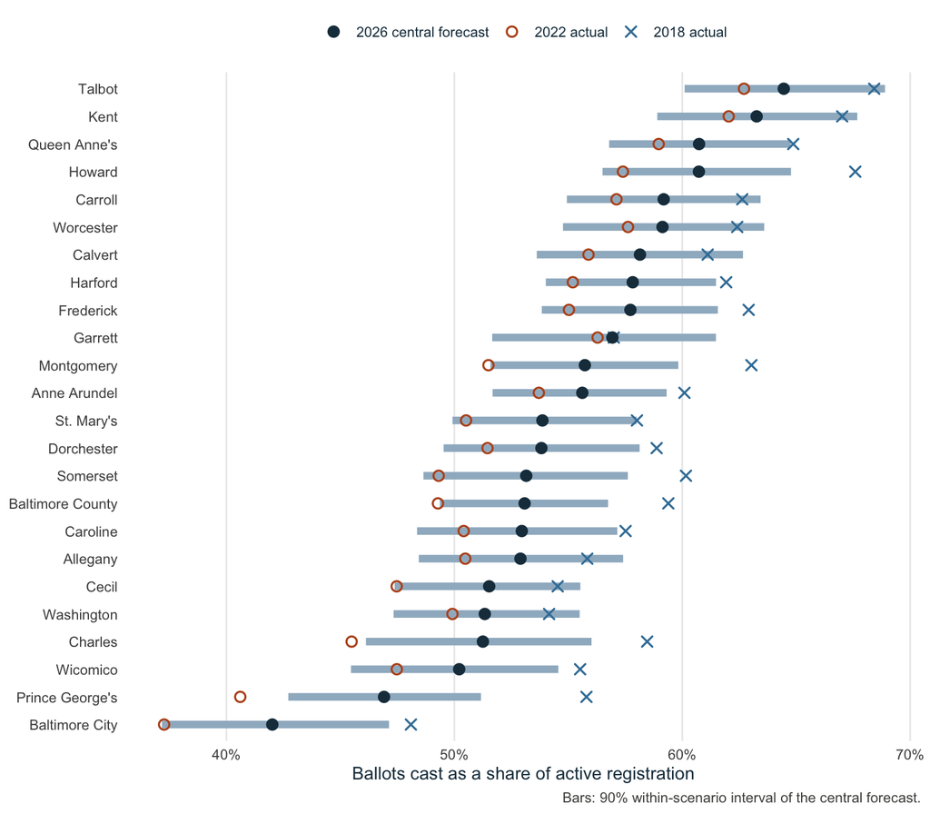

## Who votes: the electorate’s party mix

The forecast’s electorate is less Democratic than UMBC’s likely voters, with a larger share of other voters. In the central scenario, Democrats cast 53.7% of ballots, against 60% in UMBC’s sample. Other voters cast 19.8% of ballots in the central scenario, up from 16.0% in 2022. Their active registration has grown 20% since then, which drives the change.

Share of ballots cast by party group. Forecast and actual shares use registered party; the poll’s shares are as its release reports them.

| Electorate | Democrats | Republicans | Other (unaffiliated and minor) |
| --- | --- | --- | --- |
| 2026 low | 53.9% | 27.7% | 18.5% |
| 2026 central | 53.7% | 26.5% | 19.8% |
| 2026 high | 54.7% | 25.6% | 19.8% |
| 2022 actual | 55.9% | 28.1% | 16.0% |
| 2018 actual | 57.3% | 27.4% | 15.3% |
| UMBC Institute of Politics likely voters, September 22 to September 27, 2026 (n = 776, unweighted) | 60% | 25% | 15% |

The forecast’s party groups are registered party. A poll’s party shares come from its sample, which may record party as respondents describe it. Many unaffiliated registrants call themselves Democrats or Republicans when asked. Likely-voter screens also keep the respondents most certain to vote, and unaffiliated voters are the least likely to say so: UMBC’s own enthusiasm figures are lower for them. UMBC’s shares are unweighted by party, so they describe who answered, not the weighted estimate. The poll is a cross-check here and does not move the forecast.

## Composition

Composition favours turnout in every cell, but the forecast uses it only to shift turnout between counties. Older electorates and fewer brand-new registrants raise each party’s expected 2026 rate. The statewide level of that boost cannot be trusted, so it is removed.

Statewide composition factors by party (logit scale; composition_factors.csv). comp = age factor + new-registrant factor.

| Party | Age factor | New-registrant factor | Composition (comp) | County range of comp |
| --- | --- | --- | --- | --- |
| DEM | +0.035 | +0.016 | +0.051 | +0.036 (Montgomery) to +0.078 (Talbot) |
| REP | +0.049 | +0.031 | +0.080 | +0.060 (Prince George’s) to +0.099 (Queen Anne’s) |
| OTH | +0.023 | +0.011 | +0.034 | +0.021 (Montgomery) to +0.058 (Carroll) |

The five cells whose centred composition factor is largest in size. Centred = comp minus the party’s statewide weighted mean (DEM, REP, OTH: see note).

| County | Party | 2026 registrants (voter file) | comp | comp, centred within party |
| --- | --- | --- | --- | --- |
| Talbot | DEM | 11,108 | +0.078 | +0.026 |
| Somerset | DEM | 5,502 | +0.077 | +0.026 |
| Wicomico | DEM | 27,611 | +0.074 | +0.023 |
| Harford | DEM | 67,703 | +0.074 | +0.023 |
| Carroll | OTH | 36,019 | +0.058 | +0.022 |

Every scenario uses comp_centred_cp = comp_cp minus the weighted mean over counties of comp for party p (weights: 2026 projected active registration, denominators_gg26.csv). composition_factors.csv’s comp is positive in every cell (statewide DEM +0.051, REP +0.080, OTH +0.034), but its statewide level is not identified: the 2022 mix comes from today’s voter file, which lacks the ~13% of the 2022 electorate who have since died or moved, and that bias is as large as the factor. Centred, composition only redistributes turnout across counties within a party and the level comes from the calibrated scenario. central_comp_level uses the uncentred comp with the central level; its statewide difference from central is the measure ballots_minus_central in forecast_statewide.csv. The midterm structure effect s_cp is treated as describing the 2022 composition, and comp is a change from it.

The factors are centred within party for one reason. The 2022 age mix comes from today’s voter file, which lacks the roughly 13% of the 2022 electorate who have since died or moved. That gap is as large as the factor itself, so its statewide level is not identified. Using the uncentred factor as a sensitivity adds +55,851 ballots to the central forecast, +1.3 points on the rate on active registration (54.4% against 53.1%).

## How well the structure predicts a held-out midterm

Leaving out one midterm and predicting it from the other elections, the model beats a naive copy of the other midterm on 10 of 12 measures. Its county turnout rates on active registration miss by 2.2 points on average for 2022 and 2.2 for 2018. Both held-out tests calibrate statewide party totals to the actual result, so they test the county pattern, not the level.

Backtest (backtest.csv). Naive = the other midterm’s county x party rate pattern, calibrated the same way.

| Held-out election | Grain | Measure | Model | Naive | Better |
| --- | --- | --- | --- | --- | --- |
| 2022 general | County | Mean abs. error, rate on active (points) | 2.25 | 2.54 | model |
| 2022 general | County | Largest abs. error, rate on active (points) | 4.16 | 6.99 | model |
| 2022 general | County | Mean abs. error, share of state ballots (points) | 0.17 | 0.17 | naive |
| 2022 general | County x party | Mean abs. error, rate on active (points) | 2.69 | 3.02 | model |
| 2022 general | County x party | Largest abs. error, rate on active (points) | 8.68 | 12.13 | model |
| 2022 general | County x party | Mean abs. error, share of state ballots (points) | 0.06 | 0.07 | model |
| 2018 general | County | Mean abs. error, rate on active (points) | 2.17 | 2.52 | model |
| 2018 general | County | Largest abs. error, rate on active (points) | 8.08 | 7.08 | naive |
| 2018 general | County | Mean abs. error, share of state ballots (points) | 0.12 | 0.14 | model |
| 2018 general | County x party | Mean abs. error, rate on active (points) | 2.63 | 3.04 | model |
| 2018 general | County x party | Largest abs. error, rate on active (points) | 11.34 | 11.36 | model |
| 2018 general | County x party | Mean abs. error, share of state ballots (points) | 0.05 | 0.06 | model |

The three counties with the largest model error in each held-out midterm (computed from backtest_cells.csv and training.csv’s active registration).

| Held-out election | County | Actual rate on active | Model error (points) | Naive error (points) |
| --- | --- | --- | --- | --- |
| 2018 general | Garrett | 57.0% | +8.1 | +7.1 |
| 2018 general | Washington | 54.2% | +4.5 | +4.8 |
| 2018 general | Allegany | 55.8% | +4.1 | +3.5 |
| 2022 general | Garrett | 56.3% | -4.2 | -7.0 |
| 2022 general | Kent | 62.0% | -4.1 | -4.0 |
| 2022 general | Prince George’s | 40.6% | +4.0 | +4.2 |

The model loses to naive in 2 places:

- Held-out 2022, county mean error in share of state ballots: model 0.17, naive 0.17 points.
- Held-out 2018, county largest error in rate: model 8.08, naive 7.08 points. Both methods miss worst in Garrett.

## How the votes will be cast

Mail ballots make up a smaller share of the forecast vote than in 2022, 24.7% against 26.7%. The largest mode is election day, at 52.9%.

Statewide ballots cast by mode, central scenario (mode_split.csv).

| Mode | Ballots cast, 2026 central | Share, 2026 central | Share, 2022 actual |
| --- | --- | --- | --- |
| Mail-in | 563,291 | 24.7% | 26.7% |
| Early voting | 441,147 | 19.3% | 18.7% |
| Election day | 1,206,701 | 52.9% | 51.5% |
| Provisional | 71,140 | 3.1% | 3.1% |
| Total | 2,282,279 | 100.0% | 100.0% |

Mail ballots are the projected number sent, 655,014 statewide, times a return rate of 86.0%. The return rate is each county’s average of the 2022 and 2024 general elections (ballots received over ballots sent). The projection extends a straight line through the daily counts of ballots sent to the October 27 request deadline. It assumes no ballots are sent after that date. Provisional ballots keep their 2022 share of each county’s vote, and the rest splits between early voting and election day in 2022’s proportions. No county hit the cap of 90% of its ballots by mail.

Central scenario by county and mode. County ballots are rounded to sum to the statewide total.

| County | Ballots cast | Mail-in | Early voting | Election day | Provisional | Mail share | Mail share, 2022 | Return rate |
| --- | --- | --- | --- | --- | --- | --- | --- | --- |
| Allegany | 23,684 | 4,148 | 2,484 | 16,476 | 576 | 17.5% | 17.7% | 87.0% |
| Anne Arundel | 233,513 | 62,186 | 42,010 | 122,991 | 6,326 | 26.6% | 27.5% | 88.5% |
| Baltimore City | 173,579 | 45,706 | 28,683 | 89,056 | 10,134 | 26.3% | 31.9% | 82.6% |
| Baltimore County | 311,322 | 81,844 | 64,562 | 156,752 | 8,164 | 26.3% | 28.6% | 86.3% |
| Calvert | 40,817 | 9,006 | 9,693 | 21,391 | 727 | 22.1% | 23.7% | 88.0% |
| Caroline | 12,133 | 1,573 | 2,283 | 8,134 | 143 | 13.0% | 13.1% | 86.7% |
| Carroll | 77,049 | 15,191 | 15,050 | 45,608 | 1,200 | 19.7% | 20.0% | 87.8% |
| Cecil | 38,110 | 6,527 | 7,132 | 23,724 | 727 | 17.1% | 17.3% | 85.2% |
| Charles | 66,935 | 13,124 | 14,797 | 37,263 | 1,751 | 19.6% | 21.6% | 85.4% |
| Dorchester | 13,063 | 2,268 | 2,341 | 8,270 | 184 | 17.4% | 19.1% | 89.2% |
| Frederick | 120,048 | 27,991 | 17,766 | 71,407 | 2,884 | 23.3% | 23.3% | 87.2% |
| Garrett | 12,027 | 1,818 | 2,497 | 7,546 | 166 | 15.1% | 15.0% | 89.0% |
| Harford | 114,726 | 20,213 | 24,861 | 67,690 | 1,962 | 17.6% | 18.1% | 86.8% |
| Howard | 146,096 | 35,457 | 30,014 | 77,235 | 3,390 | 24.3% | 25.9% | 86.5% |
| Kent | 9,118 | 1,766 | 2,085 | 5,087 | 180 | 19.4% | 21.0% | 88.2% |
| Montgomery | 391,310 | 121,088 | 66,167 | 188,393 | 15,662 | 30.9% | 34.2% | 85.2% |
| Prince George’s | 292,294 | 74,193 | 65,372 | 139,816 | 12,913 | 25.4% | 28.4% | 85.0% |
| Queen Anne’s | 25,373 | 4,172 | 6,877 | 13,844 | 480 | 16.4% | 16.4% | 87.4% |
| Somerset | 7,837 | 1,185 | 1,588 | 4,901 | 163 | 15.1% | 16.0% | 85.6% |
| St. Mary’s | 42,430 | 7,883 | 10,179 | 23,481 | 887 | 18.6% | 19.3% | 86.1% |
| Talbot | 18,635 | 3,990 | 5,631 | 8,763 | 251 | 21.4% | 23.7% | 89.3% |
| Washington | 51,949 | 10,631 | 7,713 | 32,644 | 961 | 20.5% | 20.3% | 86.9% |
| Wicomico | 33,834 | 6,282 | 6,770 | 20,008 | 774 | 18.6% | 19.6% | 86.6% |
| Worcester | 26,397 | 5,049 | 4,592 | 16,221 | 535 | 19.1% | 20.2% | 87.3% |

## What this cannot see

- **Election-day weather.** Rain or snow on November 3 would cut election-day voting, forecast at 52.9% of ballots cast.
- **Late changes in the races.** The governor’s race polls at Moore +27 (UMBC). A tightening race, or a hot down-ballot contest, could lift turnout above the rule’s blend.
- **Changes to mail voting.** A court ruling, or a change to a deadline for mail ballots, would break the mail projection.
- **A registration surge after September.** The denominators come from September 2026 active registration.
- **Survivor bias in composition.** The 2022 age mix is built from today’s voter file, which lacks people who died or moved since 2022.
- **The 2026 primary’s party split is estimated.** The board has not yet published 2026 primary turnout by party, so the split comes from the voter file.
- **The 2014 general is left out.** The structure rests on 2018 and later elections.
- **Two different denominators.** The board’s 2018 to 2024 turnout sheets divide by active registration. Its 2026 guide divides by all eligible voters, active plus inactive. This report shows both.

## Data and reproducibility

Run the whole model and this report from the repo root, after `make build-db`:

```
make turnout-model
```

The scripts use the renv project in `scripts/turnout_model/` (`renv.lock`); see `scripts/turnout_model/README.md`. The forecast reads the board’s mail-in files through October 16, 2026. Every input and output has a provenance file:

Model inputs and outputs, each with its provenance file and run date.

| File | Provenance file | Made by | Run |
| --- | --- | --- | --- |
| data/turnout_model/inputs/covariates.csv | data/turnout_model/inputs/covariates_provenance.json | 01_build_inputs.R | 2026-10-17 |
| data/turnout_model/inputs/denominators_gg26.csv | data/turnout_model/inputs/denominators_gg26_provenance.json | 01_build_inputs.R | 2026-10-17 |
| data/turnout_model/inputs/inactive_ratio.csv | data/turnout_model/inputs/inactive_ratio_provenance.json | 01_build_inputs.R | 2026-10-17 |
| data/turnout_model/inputs/indices.csv | data/turnout_model/inputs/indices_provenance.json | 01_build_inputs.R | 2026-10-17 |
| data/turnout_model/inputs/polls_2026.csv | data/turnout_model/inputs/polls_2026_provenance.json | 01_build_inputs.R | 2026-10-17 |
| data/turnout_model/inputs/training.csv | data/turnout_model/inputs/training_provenance.json | 01_build_inputs.R | 2026-10-17 |
| data/turnout_model/gg26/backtest_cells.csv | data/turnout_model/gg26/backtest_cells_provenance.json | 02_fit.R | 2026-10-17 |
| data/turnout_model/gg26/backtest.csv | data/turnout_model/gg26/backtest_provenance.json | 02_fit.R | 2026-10-17 |
| data/turnout_model/gg26/composition_factors.csv | data/turnout_model/gg26/composition_factors_provenance.json | 03_compose.R | 2026-10-17 |
| data/turnout_model/gg26/election_level_draws.csv.gz | data/turnout_model/gg26/election_level_draws_provenance.json | 02_fit.R | 2026-10-17 |
| data/turnout_model/gg26/election_levels.csv | data/turnout_model/gg26/election_levels_provenance.json | 02_fit.R | 2026-10-17 |
| data/turnout_model/gg26/forecast_county_party.csv | data/turnout_model/gg26/forecast_county_party_provenance.json | 04_forecast.R | 2026-10-17 |
| data/turnout_model/gg26/forecast_county.csv | data/turnout_model/gg26/forecast_county_provenance.json | 04_forecast.R | 2026-10-17 |
| data/turnout_model/gg26/forecast_statewide.csv | data/turnout_model/gg26/forecast_statewide_provenance.json | 04_forecast.R | 2026-10-17 |
| data/turnout_model/gg26/level_rule.csv | data/turnout_model/gg26/level_rule_provenance.json | 04_forecast.R | 2026-10-17 |
| data/turnout_model/gg26/level_rule_text.csv | data/turnout_model/gg26/level_rule_text_provenance.json | 04_forecast.R | 2026-10-17 |
| data/turnout_model/gg26/mode_split.csv | data/turnout_model/gg26/mode_split_provenance.json | 04_forecast.R | 2026-10-17 |
| data/turnout_model/gg26/reference_levels.csv | data/turnout_model/gg26/reference_levels_provenance.json | 04_forecast.R | 2026-10-17 |
| data/turnout_model/gg26/structure_draws.csv.gz | data/turnout_model/gg26/structure_draws_provenance.json | 02_fit.R | 2026-10-17 |
| data/turnout_model/gg26/structure_effects.csv | data/turnout_model/gg26/structure_effects_provenance.json | 02_fit.R | 2026-10-17 |
| data/turnout_model/gg26/fit_summary.json | (self-describing) | 02_fit.R | 2026-10-17 |